# Gone but not missed?

Understanding the drivers and implications of post deletions on Bluesky

Yining Wang; Johannes B. Gruber; Yannik Peters; Olivier Rouquette; Katrin Weller

2026-04-24

# The Problem

- Social media datasets **change over time**: Users or moderators or platforms delete content
- Data collected at different points yields different results
- We know little about which posts disappear and why
- If deletion follows **systematic patterns**, observable data is biased – not random loss

[figure not shown]

# Research Questions

- **RQ1**: Which post-level and author-level factors predict deletion on Bluesky, and what is their relative importance?
- **RQ2**: Do deletion patterns create systematic bias in observable social media data

# Data Collection

## Bluesky & the AT Protocol

- Bluesky runs on the open-source **AT Protocol** — a decentralized social networking protocol
- All activity streams through a public **Firehose**: creates, reposts, likes, and **deletions**
- Content moderation happens via **labels**, not deletions → nearly all delete events are **user-initiated**
- Complete observational coverage, no rate limits or API sampling

(Bluseky is cool, find me there as well 😉 @jbgruber.bsky.social)

## Data Collection Logic

Instead of deleting posts when a DELETE event arrives, we note when the deletion arrived:

```javascript
    if (postsToDelete.length > 0) {
      await this.db
        .updateTable('post')
        .set({ deletedAt: new Date().toISOString() })
        .where('uri', 'in', postsToDelete)
        .execute()
    }
```

## Public Repo

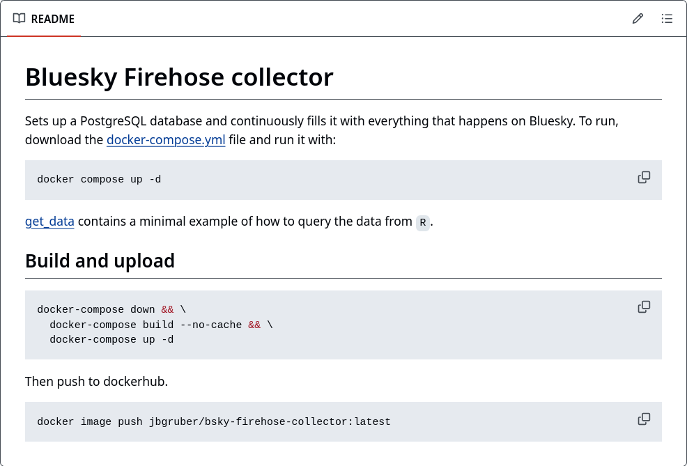

https://github.com/JBGruber/bsky-firehose-collector

## Sample

- Full dataset: 86,734,657 posts, 2,795,268 (3.22%) of which were deleted
- Collected Posts from August 2025 and deletions until 15. October
- Randomly sampled 10k deleted posts (one per author)
- Collected all non-deleted posts from the same authors

|  | deleted | not-deleted |
| --- | --- | --- |
| sample posts | 10,000 | 944,908 |
| mean date | 2025-08-15 | 2025-08-15 |
| mean likes | 1.1 | 5.4 |
| mean reposts | 0.1 | 1.0 |
| mean comments | 0.1 | 0.5 |

## Temporal Distribution

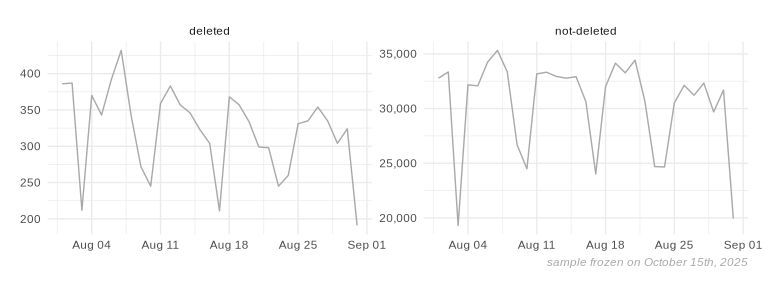

# Methods

## Data Enrichment

- Engagement measured within **24 hours** of posting (standardized window for both groups)
- Text similarity between consecutive posts by the same author: **Ratcliff/Obershelp algorithm** — proxy for error-correction behavior
- **LanguageTool** (v6.6) for direct spelling and grammar error counts
- All continuous features **log-transformed** (right-skewed distributions) and **standardized** (μ=0, σ=1)

Summary of Engineered Features

| Category | I.V. | Description | Type |
| --- | --- | --- | --- |
| Engagement | `log_likes` | Log-transformed likes (24hr) | Continuous |
|  | `log_comments` | Log-transformed comments (24hr) | Continuous |
|  | `log_reposts` | Log-transformed reposts (24hr) | Continuous |
|  | `ratio_comments_likes` | Comments/likes ratio | Continuous |
| Content | `text_length` | Character count | Continuous |
|  | `has_url` | Contains embedded link | Binary |
|  | `is_original` | Original post (vs reply) | Binary |
| Temporal | `posted_quickly` | Posted within 5 min of previous | Binary |
| Author | `author_total_posts` | User’s total posts | Continuous |
|  | `deletion_ratio_per_author` | User’s deletion rate | Continuous |
| Similarity | `similarity` | Text similarity to next post | Continuous [0,1] |
| Interaction | `low_engagement_x_similarity` | Low engagement × similarity | Continuous |
| Typo | `log_errors` | Log-transformed error count | Continuous |

## Model

- Seven logistic regression models, each adding one predictor category (hierarchical specification)
- Dependent variable: post deletion [Yes/No]
- Bias-reduced (Firth) logistic regression (deleted posts are rare, which can lead to bias)
- All continuous variables were standardised (makes odds ratios directly comparable across predictors)

# Results

## Predictors of Post Deletion on Bluesky

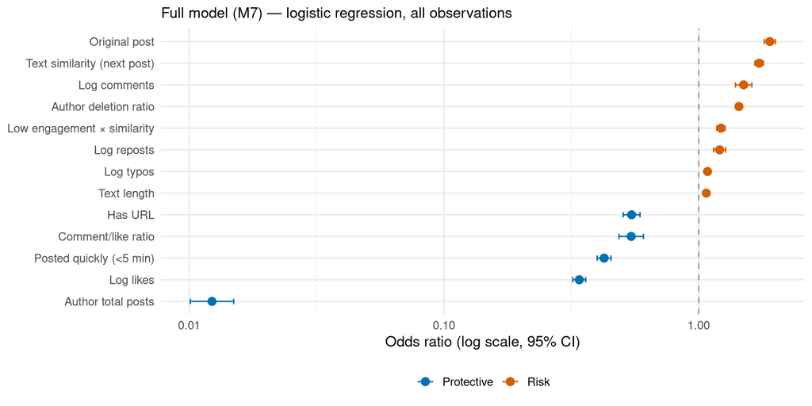

# Conclusion

## RQ2: Do deletion patterns create systematic bias

- **Bluesky’s 3.22% deletion rate creates non-random data loss** with implications for temporal validity and reproducibility
- A lot of the deletions can be explained by error correction, which is likely less important for analysis
- Posts that are deleted because of comments might be more interesting (depending on RQ)
- Users who deleted all posts might need to be studied separately – they are so far understudied

## Limitations & Next Steps

**Current limitations:**

- Data collection ended Octover 2025: deletion rates are a **lower bound** (posts could still be deleted later)
- No content analysis yet: topics, sentiment, emotions?
- One deleted post per author: cannot examine within-author selectivity
- Only looked at deleted posts (user invoked) not moderation (labels)

**Next steps:**

- Full ethics review for large-scale follow-up collection
- Collect new data
- Content analysis of deleted vs. kept posts (topics, political content, affect)
- Longitudinal design covering longer time horizons

# Ethical Considerations

**Users removed their content, so there is a clear intention that content should not be available**

- All data was publicly accessible via the Firehose at time of collection
- Collected only user IDs (no usernames), post text, and non-identifying engagement metadata
- Data minimization principle: GDPR Art. 5(1)(c)

**Important**

Presented results are from a pilot we did before receiving ethical approval, the data had to be deleted.